# HW3

Wiktoria Koniecko, Agata Osmałek

2022-11-22

# Wstęp

Przeprowadziłyśmy 2 eksperymenty:

- Porównanie statycznego wykresu punktowego 3D i 3 wykresów punktowych 2D
- Porównanie wykresu kołowego i słupkowego

Każdy eksperyment składał się z 2 części:

- Sprawdzenie dokładności, gdzie ankietowany musiał odczytać lub porównać dane
- Subiektywna ocena łatwości odczytania danych z wykresu

Ankieta została przeprowadzona z pomocą formularzy Google.

# Eksperyment 1: Badanie czytelności wykresów punktowych 2D i 3D

Badanie przeprowadzono na podstawie poniższych dwóch wykresów:

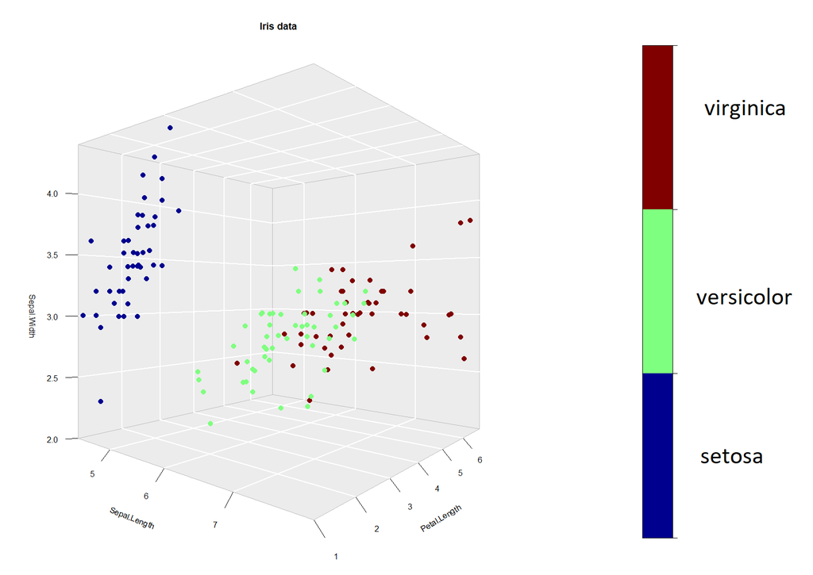

wykres 3D

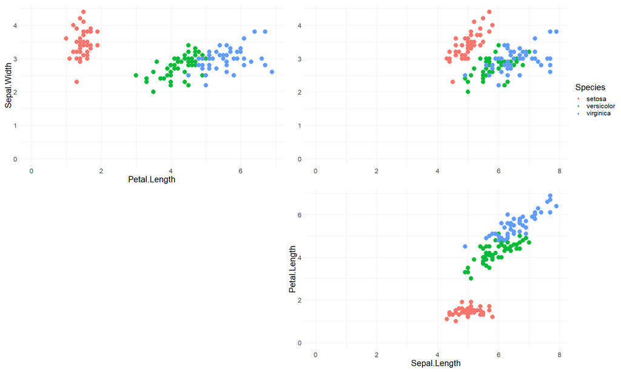

wykres 2D

## Badanie czytelności

#### Pytanie 1

Jak oceniłabyś/oceniłbyś czytelność powyższego wykresu?

##### Wykres rozkładu odpowiedzi

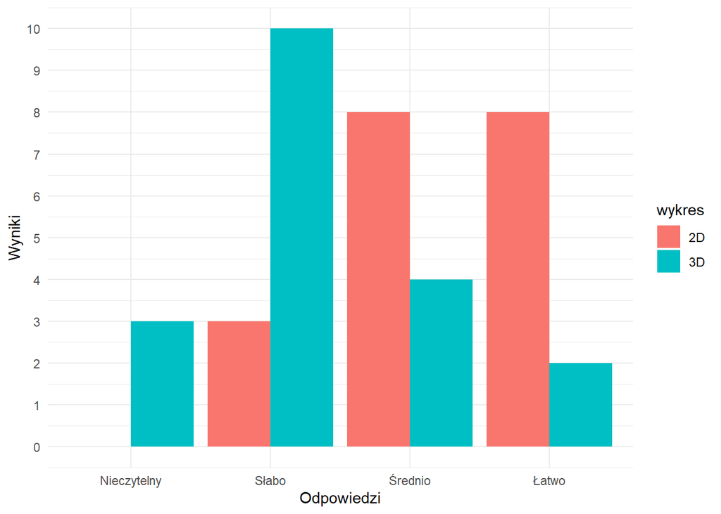

Jak widać na wykresie większość ankietowanych oceniała wykres 3D nisko: najczęściej jako słabo czytelny, z ponad 2-krotną przewagą nad drugim wyborem - średnią czytelnością. Wykres 2D otrzymał wyższe wyniki - najczęściej oceniano go jako łatwo lub średnio czytelnego oraz nie otzrymał ani razu noty nieczytelny.

#### Pytanie 2

Oceń zależność między gatunkami kwiatów.Wybierz prawdziwe zdania:

Dla wykresu 3D:

- A - Setosa ma wszystkie wartości petal.length mniejsze niż pozostałe gatunki
- B - Największe wartości Sepal.legth należą do gatunku Virginica
- C - Największe petal.length i Sepal.width obie są gatunku Virginica
- D - Największa wartość sepal.width jest gatunku Setosa
- E - Największa wartość sepal.length jest ponad dwkrotnie większa niż najmniejsza wartość Sepal.length
- F - Setosa ma wszystkie wartości sepal.length mniejsze niż pozostałe gatunki

Dla wykresu 2D:

- A - Największa wartość Petal.length są gatunku Virginica
- B - Wszystkie kwaity gatunku Versicolor mają mniejszą wartość Petal.length niż Virginica
- C - Najmniejsza wartość Sepal.length jest gatunku Setosa
- D - Największa wartość Sepal.width jest mniej niż 1,5 raza większa niż najmniejsza wartość gatunku Versicolor
- E - Najmniejsze wartości Petal.length i Sepal.width obie są gatunku Setosa
- F - Wszystkie Setosy mają Petal.length przynajmniej 2 krotnie mniejszy niż dowolna Virginica

##### Wykresy rozkładu odpowiedzi

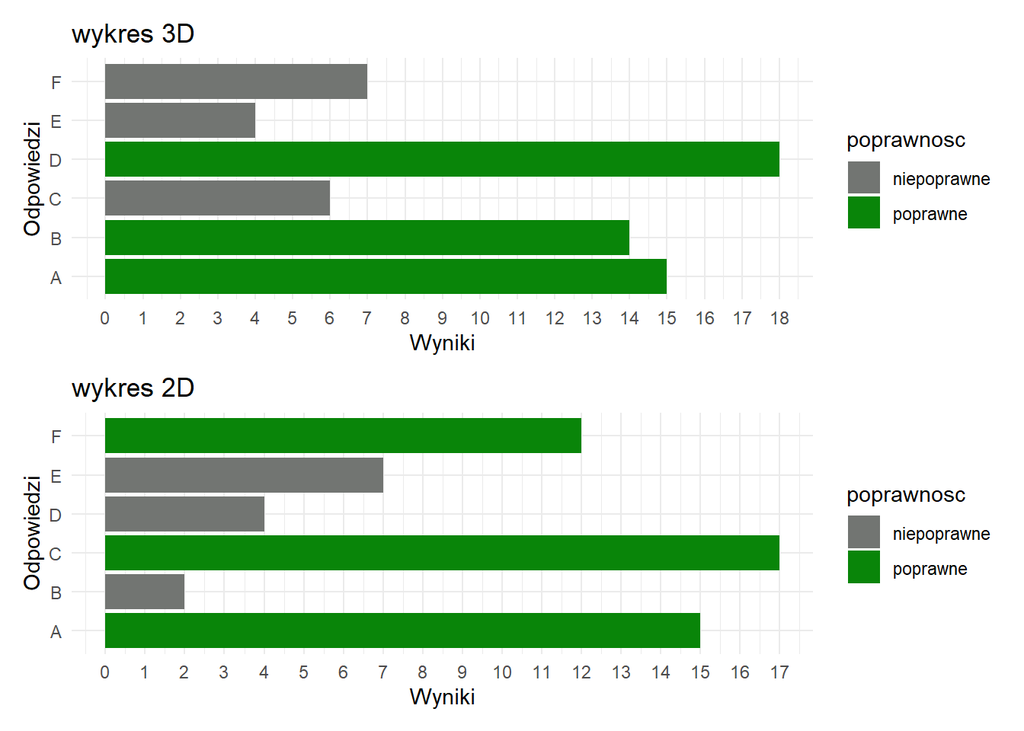

Dla obu wykresów najczęściej (z dużą przewagą) wybierane były zdania prawdziwe, jednak pojawiało się też wiele niepoprawnych odpowiedzi. Żeby móc lepiej ocenić, dla którego wykresu wyniki były lepsze można przeprowadzić analizę poprawności odpowiedzi pojedyńczych ankietowanych, patrząc na ich dokładność wg wzoru:
$$Accuracy = (TP+TN)/(TP+FP+TN+FN)$$
gdzie:

- TP - True Positive: ankietowany zaznaczył zdanie prawdziwe poprawnie
- TN - True Negative: ankietowany nie zaznaczył zdania fałszywego jako prawdziwe
- FP - False Positive: ankietowany zaznaczył zdanie fałszywe jako prawdziwe
- FN - False Negative: ankietowany nie zaznaczył zdania prawdziwego (uznał je za fałszywe)

##### Wykres dokładności odpowiedzi

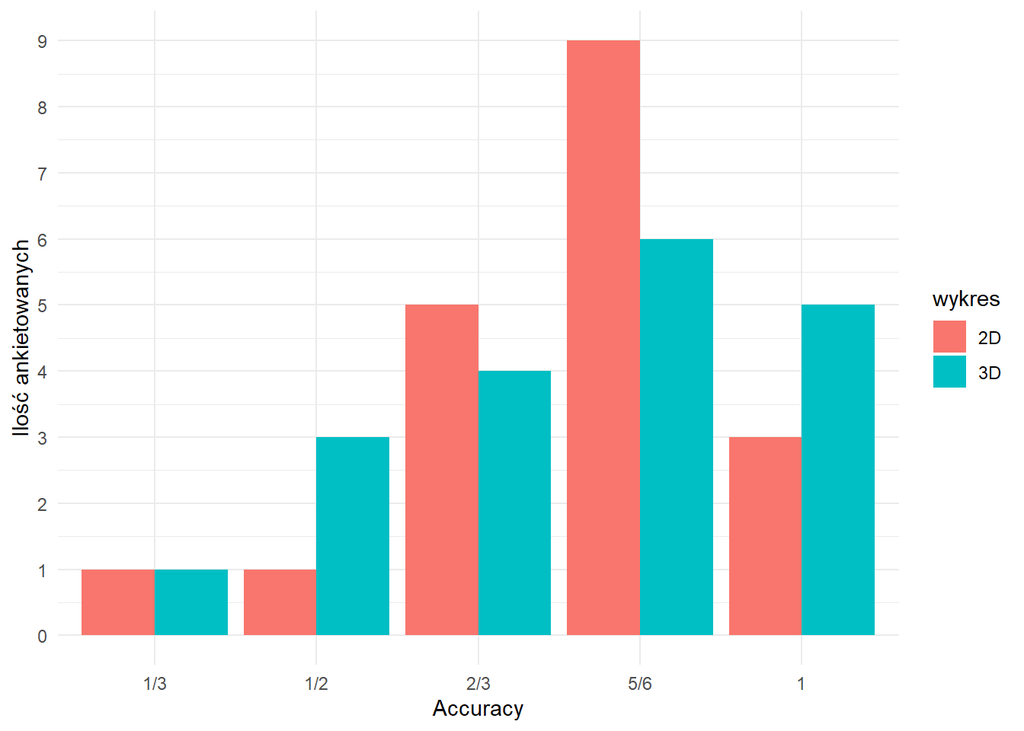

Na powyższym wykresie widać, że więcej ankietowanych udzieliło bezbłędnej odpowiedzi przy wykresie 3D, jednak dla wykresu 2D więcej osób udzieliło odpowiedzi z dokładnością 2/3 i 5/6.

Licząc średnią wartość Accuracy dla obu wykresów otrzymujemy:

- wykres 3D: AverageAccuracy ≈ 0.76316
- wykres 2D: AverageAccuracy ≈ 0.77198

Zatem ankietowani nieznacznie lepiej oceniali prawdziwość zdań dla wykresu 2D.

#### Pytanie 3

Uporządkuj najmniejsze wartość sepal.width z każdego gatunku od najmniejszej do njwiększej:

|  | wykres 3D | wykres 2D |
| --- | --- | --- |
| Setosa | największa | najmniejsza |
| Versicolor | najmniejsza | średnia |
| Virginica | średnia | największa |

##### Wykresy rozkładu odpowiedzi

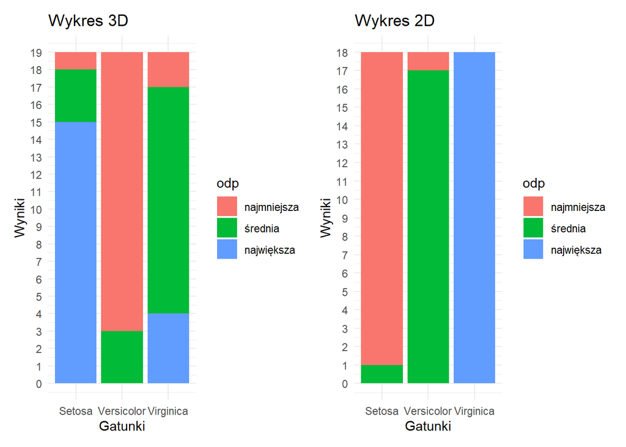

Większość ankietowanych oceniła poprawnie zależności między punktami dla obu wykresów. Jednak dla wykresu 2D błędne odpowiedzi zostały odnotowane znacznie mniejszą ilość razy niż dla wykresu 3D.

#### Pytanie 4

Odczytaj wartości dla punktu zaznaczonego różową strzałką:

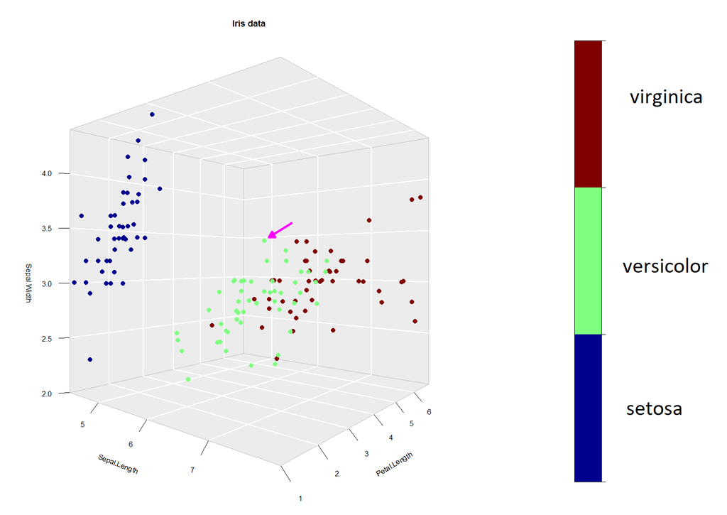

Wykres 3D

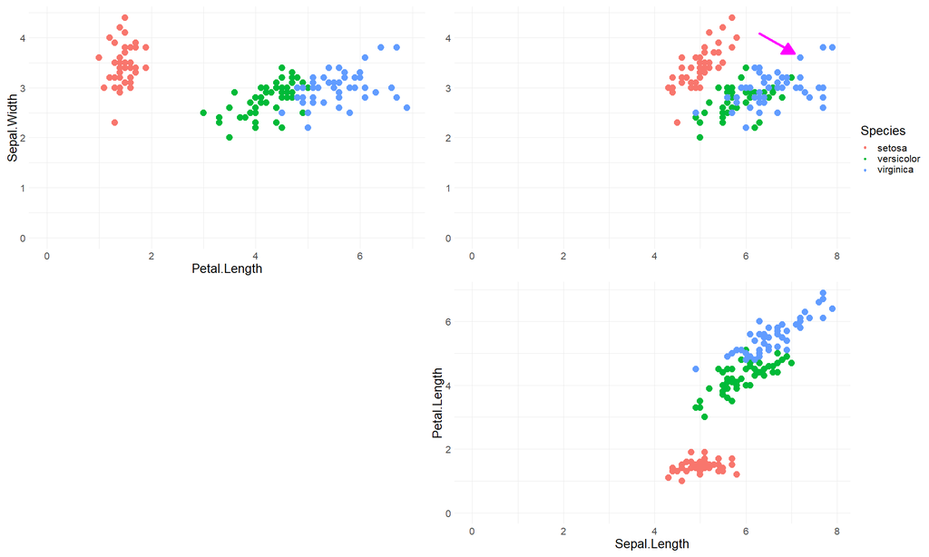

Wykres 2D

##### Wykresy rozkładu odpowiedzi

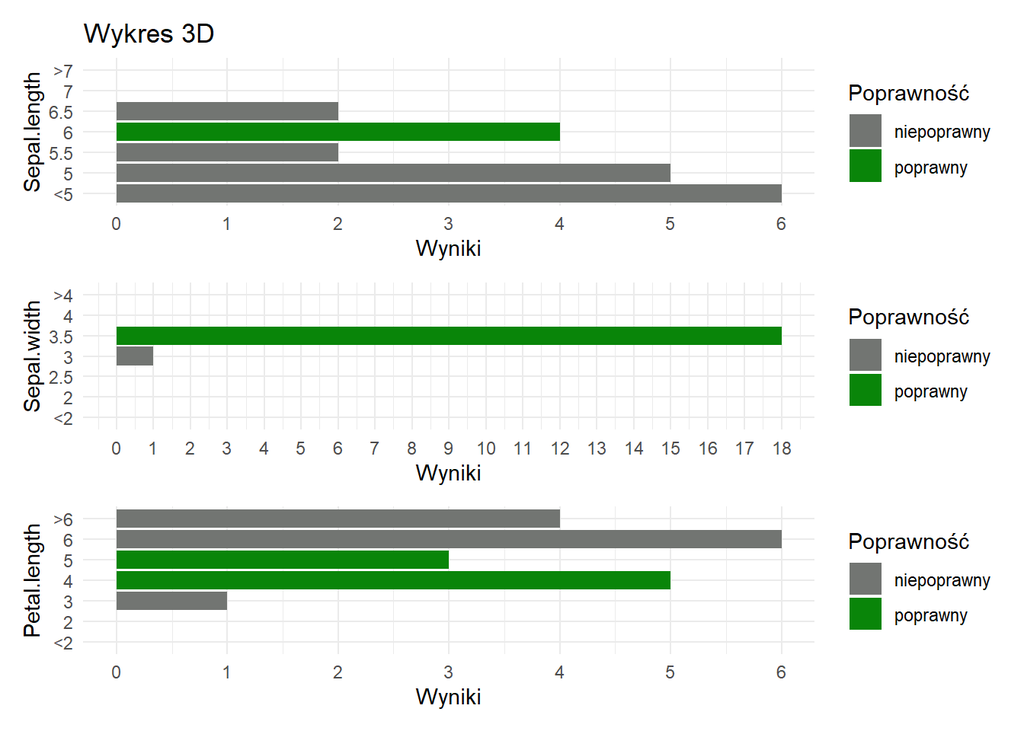

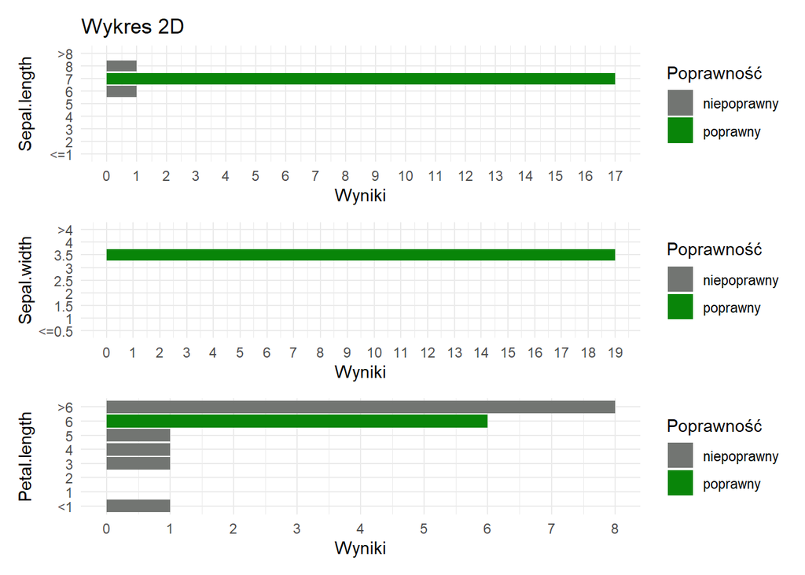

Zauważyć można też, że przy wykresie 3D błędy najczęściej występowały dla osi Sepal.length (mniej niż 1/4 ankietowanych odpowiedziała poprawnie) oraz najrzadziej dla osi Sepal.width (tylko jedna błędna odpowiedź).

Dla wykresu 2D 100% ankietowanych odczytało poprawnie wartość z osi Sepal.width, natomiast przy osi Petal.length jedynie około 1/3 odpowiedzi była poprawna. Ta duża liczba błędów dla osi Petal.length może wynikać z faktu, że ankietowany musiał odczytać wartość przenosząc zaznaczony punkt na jeden z sąsiednich wykresów.

## Subiektywne porównanie wykresów

#### Pytanie 5

Z którego wykresu łatwiej było Tobie odczytać dokładne wartości?

- Wykres 3D - 15.8% ankietowanych
- Wykres 2D - 84.2%
- Nie zauważyłam/łem różnicy - 0%

#### Pytanie 6

Na którym wykresie łatwiej było oszacować zależności między gatunkami kwiatów?

- Wykres 3D - 10.5% ankietowanych
- Wykres 2D - 78.9%
- Nie zauważyłam/łem różnicy - 10.5%

#### Pytanie 6

Który z wykresów uważasz za lepszą formę przedstawienia danych?

- Wykres 3D - 15.8% ankietowanych
- Wykres 2D - 68.4%
- Nie mam zdania - 15.8%

## Wnioski

Patrząc na wyniki ankiety z części “Badanie czytelności” można zauważyć, że niemal przy każdym pytaniu wykres 2D miał widocznie lepsze wyniki niż wykres 3D. Wyjątkami były:

- pytanie 2 - średnia poprawność odpowiedzi wykresów była zbliżona, choć 2D nadal wypadał nieznacznie lepiej
- pytanie 4 - dla osi Petal.length wykres 3D miał około 40% poprawnych odpowiedzi, a 2D jednynie nieco ponad 30%.

Wyniki z drugiej części ankiety - “Subiektywne porównanie wykresów” - potwierdzają wyniki z części pierwszej. Widać tutaj, że znacząca większość ankietowanych uważa wykres 2D za lepszą, łatwiejszą do odczytania formę przedstawiania danych.

# Eksperyment 2: Wykresy kołowy i słupkowy

### Wykres kołowy

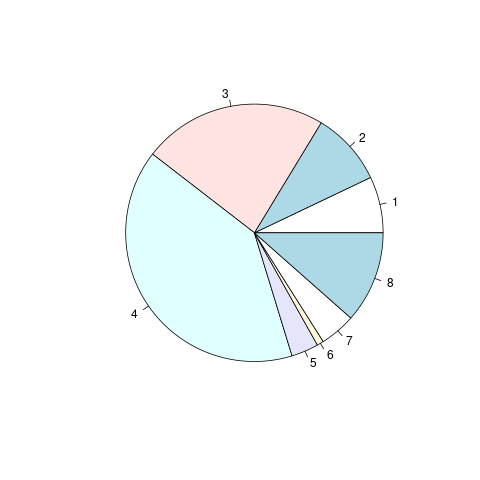

Wykresu kołowego dotyczyły 2 pytania:

- porównanie wycinków 1 (wartość ok. 0.07) i 2 (wartość ok. 0.09)
- wskazanie wartości wycinka 7 (wartość ok. 0.044).

Większość ankietowanych poprawnie porównała ze sobą 2 wycinki - 17 z 19 osób odpowiedziało, że wycinek 2 jest większy. Pozostałe odpowiedzi wskazywały, że wycinki są równe. Ponad połowa osób biorących udział w badaniu nie była jednak w stanie poprawnie odczytać dokładnej wartości wycinka.

Wycinek nr 7, którego rozmiar miał zostać określony zajmował ok. 4,5% koła.

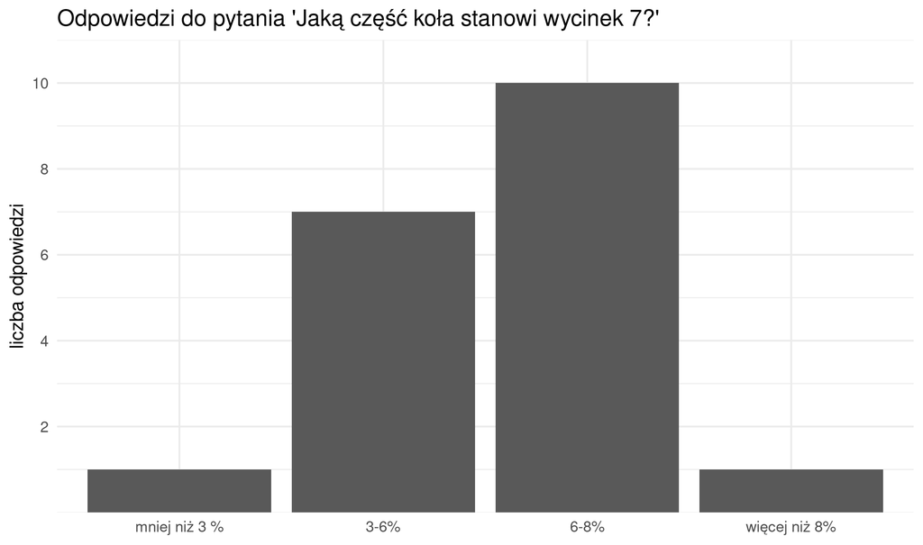

### Wykres słupkowy

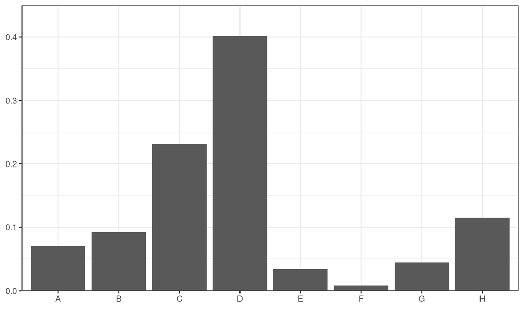

Wykresu słupkowego dotyczyły 2 pytania:

Każdy ankietowany poprawnie porównał ze sobą słupki E i G.

Określając wysokość słupka C, pomyliła się tylko 1 osoba (wskazała odpowiedź “większy, niż 0,27”), pozostali poprawnie wskazali przedział 0.22-0.25.

### Wygoda odczytu

Wszyscy ankietowani stwierzdzili, że z wykresu słupkowego łatwiej było im zarówno odczytywać, jak i porównywać dane.

### Wniosek

Wykresy kołowe utrudniają prawidłowy odczyt danych.